# Data Preprocessing and cleaning

LIBRERIE

```r
library(dplyr)
library(sf)
library(osmdata)
library(ggplot2)
library(ggmap)
```

DATA IMPORT

```r
rm(list=ls()) # remove all variables

# dati del 2023
dati2023 <- read.csv("dati/Dati_sensori_aria_2023.csv")
dati2018 <- read.csv("dati/Dati_sensori_aria_dal_2018.csv")

# import station dataset
stationData1 <- read.csv("dati/Stazioni_qualit__dell_aria_2024.csv")
stationData2 <- read.csv("dati/Stazioni_qualit__dell_aria_NRT_2024.csv")
```

Concatenazione dei dataset delle rilevazioni

```r
# I due dataset han formati diversi per la data !!!!!!!!

# convert time in a 24h format
dati2018$Data  <- strptime(dati2018$Data, format = "%m/%d/%Y %I:%M:%S %p")

# convert time in a 24h format
dati2023$Data  <- strptime(dati2023$Data, format = "%d/%m/%Y %I:%M:%S %p")

#tengo solo i dati del 2023
dati23 <- subset(dati2018, format(Data, "%Y") == "2023")
dati2023 <- subset(dati2023, format(Data, "%Y") == "2023")

# concateno i due dataset
airData <- rbind(dati2023, dati23)
# check on the year
unique(format(airData$Data, "%Y"))
```

```
[1] "2023"
```

Concatenazione dei dataset delle stazioni

```r
stationData2$Quota <- as.character(stationData2$Quota)
stationData <- bind_rows(stationData1, stationData2)

rm(list=c("stationData1", "stationData2","dati2018", "dati23","dati2023"))
```

NULL INSTANCES

```r
# count null instances
nrow(airData[airData$Valore == -9999.0,])
```

```
[1] 73174
```

```r
# save the instance with errors to study them
#errorSensor <- airData[airData$Valore == -9999.0,]

# remove null instances
airData <- airData[airData$Valore != -9999.0,]

airData <- subset(airData, !is.na(Data))
```

DUPLICATE INSTANCES

```r
# check for duplicate instances
nrow(distinct(airData)) == nrow(airData)
```

```
[1] FALSE
```

```r
length(unique(stationData$IdSensore)) == nrow((stationData))
```

```
[1] FALSE
```

```r
# rimuove misurazioni doppie
airData <- airData %>% distinct()

# rimuovi duplicati sensori
stationData <- stationData %>% distinct(IdSensore, .keep_all = TRUE)
```

OPEN ATTRIBUTE

```r
# create new attribute for the station
stationData$Open <- ifelse((stationData$DataStop == "" | is.na(stationData$DataStop)), "YES", "NO")
```

LOMBARDIA MAP

```r
# download Lombardia map
lombardiaMap <- get_stadiamap((getbb("Lombardia")), maptype = "outdoors", zoom=8 )
```

```
ℹ © Stadia Maps © Stamen Design © OpenMapTiles © OpenStreetMap contributors.
```

PLOT DETECTION STATION

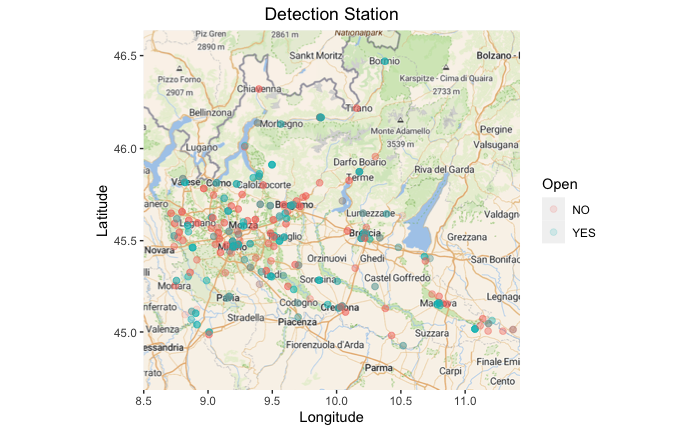

```r
# plot the detection station
plot <- ggmap(lombardiaMap) + geom_point(data = stationData,
                     aes(x = lng, y = lat, color = Open), size = 2, alpha = 0.15) +
                     ggtitle("Detection Station") +
                     labs(x = "Longitude", y = "Latitude") +
                     theme(plot.title = element_text(hjust = 0.5))
plot
```

PLOT DETECTION STATION

```r
color_scale <- scale_color_manual(values = c("red", "green"))

# Read the GeoJSON Shapefile
lombardia_provinces <- st_read("dati/lombardy_.geojson")
plot <- ggplot() +
  geom_sf(data = lombardia_provinces, fill = "lightblue", color = "black") +
  # Add points from stationData
  geom_point(data = stationData, aes(x = lng, y = lat, color= Open), size = 2) +
  labs(x = "Longitude", y = "Latitude") +
  color_scale +
  theme_minimal() +
  theme(legend.position = "top")
ggsave(plot, file="detectionStation.pdf", width = 5, height = 5)
```

DATASET MERGE

```r
fullData <- merge(airData, stationData, by = "IdSensore")

# save the lost instances
# lostInstances <- anti_join(airData, fullData, by = "IdSensore")

rm(airData)
```

MAPPING + creazione sigla sostanza

```r
# Creiamo una tabella di corrispondenza tra i valori e le sigle
tabella_corrispondenza <- data.frame(
  NomeTipoSensore = c("Ammoniaca", "Arsenico", "Benzene","Biossido di Azoto","Biossido di Zolfo","BlackCarbon","Cadmio","Monossido di Azoto","Monossido di Carbonio", "Nikel", "Ossidi di Azoto", "Ozono", "Piombo", "Particelle sospese PM2.5", "PM10 (SM2005)"),
  Sigla = c("NH3", "As", "C6H6", "NO2", "SO2", "BC", "Cd", "NO", "CO", "Ni", "NOX", "O3", "Pb", "PM2.5", "PM10")
)

# Uniamo la tabella di corrispondenza al dataset per aggiungere la colonna 'sigla'
fullData <- merge(fullData, tabella_corrispondenza, by = "NomeTipoSensore", all.x = TRUE)
```

PLOT MEASURED SUBSTANCE BY PROVINCE

```r
# generate a scatterplot showing which types of substances are measured in which
plot <- ggplot(fullData, aes(x = Provincia, y = Sigla)) +
                geom_point() +
                labs(x = "Zone", y ="Measured Substance")+
                theme_minimal() +  theme(
                axis.text.x = element_text(size = 16),  # Adjust the 'size' parameter as needed
                axis.text.y = element_text(size = 16))
ggsave(plot, file="sostanzeProvince.png", width = 8, height = 5)
```

PLOT INSTANCES NUMBER

```r
# find number of instances for each substance
instanceNumber <- as.data.frame(table(fullData$NomeTipoSensore))
instanceNumber$Var1 <- c("NH3", "As", "C6H6", "NO2", "SO2", "BC", "Cd", "NO", "CO", "Ni", "NOX", "O3", "Pb", "PM2.5", "PM10")

custom_values <- instanceNumber$Freq
custom_labels <- instanceNumber$Var1[which(instanceNumber$Freq %in% custom_values)]


pdf("sostanzeIstanze.pdf", width = 8, height = 5)  # Adjust width and height as needed
plot <- barplot(instanceNumber$Freq, names.arg = custom_labels, horiz = TRUE, las = 1, col = "transparent", cex.names = 0.9)
dev.off() #close the pdf device
```

```r
rm(instanceNumber)
```

PROVINCE COORDINATES

```r
# Create a data frame with province, latitude, and longitude
province <- data.frame(
  Provincia = c("BS", "BG", "CO", "CR", "LC", "LO", "MN", "MI", "MB", "PV", "SO", "VA"),
  lat = c(45.5397733, 45.6947359, 45.8119642, 45.1334974, 45.8529825, 45.3128778, 45.1603653, 45.4636707, 45.5840057, 45.1858767, 46.1712597, 45.8176046),
  lng = c(10.2229390, 9.6687071, 9.0854556, 10.0261350, 9.3900705, 9.4978501, 10.7976976, 9.1881263, 9.2730143, 9.1566316, 9.8693336, 8.8263844)
)


#https://www.dossier.net/utilities/coordinate-geografiche/provincia-monza-brianza.htm
```

CADMIO - PIOMBO - ARSENICO - NICHEL

```r
arsenico <- fullData [fullData$NomeTipoSensore == "Arsenico",]
piombo <- fullData [fullData$NomeTipoSensore == "Piombo",]
cadmio <- fullData [fullData$NomeTipoSensore == "Cadmio",]
nikel<- fullData [fullData$NomeTipoSensore == "Nikel",]

# Sample data for 4 instances
measurements <- c(piombo$Valore, arsenico$Valore, cadmio$Valore, nikel$Valore)

# Limit value
limit_values <- c(0.5, 6, 5, 20)
names <- c("Pb", "As", "Cd", "Ni")
colors <- c("red", "lightblue", "green","blue")

# Create a bar plot
barplot(measurements, names.arg = names, col = colors[2], main = "Measurement for 4 Instances", ylab = "Measurement Value", ylim=c(0, 22))

for (i in seq_along(limit_values)) {
  abline(h = limit_values[i], col = colors[i], lty = 2)
}

# Print messages indicating the limit values
for (i in seq_along(limit_values)) {
  text(i, limit_values[i], paste("Limit", names[i]), col = colors[i], pos = 3)
}

rm(list = c("custom_labels", "custom_values", "cadmio", "piombo", "nikel", "arsenico", "colors", "i", "limit_values", "measurements", "names"))
```

BLACK CARBON Calcolo le medie mensili delle misurazioni di Black Carbon per stazione

```r
blackCarbon <- fullData [fullData$NomeTipoSensore == "BlackCarbon",]

# Extract Year and Month from the 'Data' column
BC <- blackCarbon %>%
  mutate(Year = lubridate::year(Data),
         Month = lubridate::month(Data))

# Group by 'IdStazione', 'Year', and 'Month', and calculate the mean of 'Valore'
monthlyMeanBc <- BC %>%
  group_by(IdStazione, Year, Month) %>%
  summarise(Mean_Value = mean(Valore, na.rm = TRUE))
monthlyMeanBc <- merge(monthlyMeanBc,stationData[stationData$NomeTipoSensore == "BlackCarbon",], by="IdStazione")

# Use distinct to remove duplicates based on 'IdStazione', 'Year', and 'Month'
monthlyMeanBc <- monthlyMeanBc %>% distinct(IdStazione, Year, Month, .keep_all = TRUE)
head(monthlyMeanBc)
```

|  | IdStazione | Year | Month | Mean_Value | IdSensore | NomeTipoSensore | UnitaMisura | NomeStazione | Quota | Provincia | Comune | Storico | DataStart | DataStop | UTM_Nord | UTM_Est | lat | lng | location | Open |
| --- | --- | --- | --- | --- | --- | --- | --- | --- | --- | --- | --- | --- | --- | --- | --- | --- | --- | --- | --- | --- |
| 1 | 501 | 2023 | 1 | 3.587366 | 20455 | BlackCarbon | µg/m³ | Milano v.Marche | 129 | MI | Milano | N | 25/11/2020 |  | 5038105 | 514918 | 45.49632 | 9.190934 | (45.49631644365102, 9.190933555313624) | YES |
| 2 | 501 | 2023 | 2 | 3.356250 | 20455 | BlackCarbon | µg/m³ | Milano v.Marche | 129 | MI | Milano | N | 25/11/2020 |  | 5038105 | 514918 | 45.49632 | 9.190934 | (45.49631644365102, 9.190933555313624) | YES |
| 3 | 501 | 2023 | 3 | 2.142127 | 20455 | BlackCarbon | µg/m³ | Milano v.Marche | 129 | MI | Milano | N | 25/11/2020 |  | 5038105 | 514918 | 45.49632 | 9.190934 | (45.49631644365102, 9.190933555313624) | YES |
| 4 | 501 | 2023 | 4 | 1.595480 | 20455 | BlackCarbon | µg/m³ | Milano v.Marche | 129 | MI | Milano | N | 25/11/2020 |  | 5038105 | 514918 | 45.49632 | 9.190934 | (45.49631644365102, 9.190933555313624) | YES |
| 5 | 501 | 2023 | 5 | 1.596624 | 20455 | BlackCarbon | µg/m³ | Milano v.Marche | 129 | MI | Milano | N | 25/11/2020 |  | 5038105 | 514918 | 45.49632 | 9.190934 | (45.49631644365102, 9.190933555313624) | YES |
| 6 | 501 | 2023 | 6 | 1.480532 | 20455 | BlackCarbon | µg/m³ | Milano v.Marche | 129 | MI | Milano | N | 25/11/2020 |  | 5038105 | 514918 | 45.49632 | 9.190934 | (45.49631644365102, 9.190933555313624) | YES |

Calcolo le medie annuali per stazione

```r
# Group by 'IdStazione' and 'Year', and calculate the mean of 'Mean_Value'
yearlyMeanBc <- monthlyMeanBc %>%
  group_by(IdStazione, Year) %>%
  summarise(YearlyMeanValue = mean(Mean_Value, na.rm = TRUE))
yearlyMeanBc <- merge(yearlyMeanBc, stationData[stationData$NomeTipoSensore == "BlackCarbon",], by="IdStazione")

# Use distinct to remove duplicates based on 'IdStazione', 'Year', and 'Month'
yearlyMeanBc <- yearlyMeanBc %>% distinct(IdStazione, Year, .keep_all = TRUE)

# Display the resulting dataset
head(yearlyMeanBc)
```

|  | IdStazione | Year | YearlyMeanValue | IdSensore | NomeTipoSensore | UnitaMisura | NomeStazione | Quota | Provincia | Comune | Storico | DataStart | DataStop | UTM_Nord | UTM_Est | lat | lng | location | Open |
| --- | --- | --- | --- | --- | --- | --- | --- | --- | --- | --- | --- | --- | --- | --- | --- | --- | --- | --- | --- |
| 1 | 501 | 2023 | 2.426613 | 20455 | BlackCarbon | µg/m³ | Milano v.Marche | 129 | MI | Milano | N | 25/11/2020 |  | 5038105 | 514918 | 45.49632 | 9.190934 | (45.49631644365102, 9.190933555313624) | YES |
| 2 | 548 | 2023 | 1.384554 | 20465 | BlackCarbon | µg/m³ | Milano v.Senato | 118 | MI | Milano | N |  |  | 5035238 | 515435 | 45.47050 | 9.197460 | (45.470499014097, 9.197460360112531) | YES |
| 3 | 705 | 2023 | 1.728806 | 20004 | BlackCarbon | µg/m³ | Milano Pascal Città Studi | 122 | MI | Milano | N | 30/09/2013 |  | 5036190 | 518405 | 45.47900 | 9.235491 | (45.47899606168744, 9.235491038497502) | YES |

Plot the monthly trend

```r
# Convert 'Month' to a factor with correct levels
monthlyMeanBc$Month <- factor(monthlyMeanBc$Month, levels = c("1", "2", "3", "4", "5", "6", "7", "8", "9", "10", "11", "12"))

# Create a ggplot object
plot <- ggplot(monthlyMeanBc, aes(x = Month, y = Mean_Value, group = interaction(IdStazione, Year), color = as.factor(IdStazione), linetype = factor(IdStazione))) +
  geom_line() +
  geom_point() +
  labs(#title = "Trend of Mean Value Over Months",
       x = "Month",
       y = "Average Value",
       color = "IdStazione",
       linetype = "IdStazione") +
  scale_linetype_discrete(name = "IdStazione") +
  theme_minimal() + theme(plot.title = element_text(hjust = 0.5)) + # Center the title
  theme(plot.title = element_text(hjust = 0.5),
        axis.text.x = element_text(size = 14),  # Adjust the 'size' parameter as needed
        axis.text.y = element_text(size = 14),
        axis.title.x = element_text(size = 16),  # Adjust the 'size' parameter as needed
        axis.title.y = element_text(size = 16),
        legend.position = "top")  # Change the legend position here)
ggsave(plot, file="trendBC.pdf", width = 8, height = 5)

rm(list = c("BC", "monthlyMeanBc", "blackCarbon", "yearlyMeanBc"))
```

PM10 Creo il dataset + plot delle stazioni

```r
PM10 <- fullData [fullData$NomeTipoSensore == "PM10 (SM2005)",]
# daily limit is 50 μg/m3 hourly average, and must not to be exceeded more than 35 days/year.
# Annual limit is less than 40 μg/m3 on an yearly average.

# plot the detection station
plot <- ggmap(lombardiaMap) + geom_point(data = PM10,
                     aes(x = lng, y = lat), size = 2, alpha = 0.15) +
                     ggtitle("PM10 Detection Station") +
                     labs(x = "Longitude", y = "Latitude") +
                     theme(plot.title = element_text(hjust = 0.5))
```

Calcolo: - il numero di giorni in cui viene superato il limite (per provincia) - la media annua per stazione - la media annua per provincia

```r
# NUMBER OF DAYS OVER LIMIT

# Filter rows where Valore is greater than 50, count distinct days where Valore is greater than 50 for each province
PM10OverLimit <- PM10 %>%
  filter(Valore > 50)%>%
  group_by(Provincia, Data) %>%
  group_by(Provincia) %>%
  summarize(DaysAbove50 = sum(n_distinct(Data)))

# ANNUAL AVG BY STATION AND BY PROVINCE
# Convert 'Data' column to Date type
PM10$Data <- as.Date(PM10$Data)

# Calculate the annual average grouped by IdStazione for the year 2023
PM10_annual_avg_by_station <- PM10 %>%
  filter(lubridate::year(Data) == 2023) %>%
  group_by(IdStazione) %>%
  summarise(Avg_Valore_Station = mean(Valore, na.rm = TRUE))

# Calculate the annual average grouped by Provincia
PM10_annual_avg_by_province <- PM10_annual_avg_by_station %>%
  left_join(PM10 %>% select(IdStazione, Provincia) %>% distinct(), by = "IdStazione") %>%
  group_by(Provincia) %>%
  summarise(Avg_Valore_Province = mean(Avg_Valore_Station, na.rm = TRUE))

# Adding lat and lng for station
PM10_annual_avg_by_station <- merge(PM10_annual_avg_by_station, stationData[stationData$NomeTipoSensore == "PM10 (SM2005)",])

# Adding lat and lng for provinces
PM10_annual_avg_by_province <- merge(PM10_annual_avg_by_province, province, by="Provincia")
```

Plot: rispetto limiti giornaliero + rispetto limiti annuo

```r
# Create a new variable for color based on the condition
PM10OverLimit$color <- ifelse(PM10OverLimit$DaysAbove50 < 35, "lightgreen", "red")

# Create a bar plot
plot <- ggplot(PM10OverLimit, aes(x = Provincia, y = DaysAbove50, fill = color)) +
  geom_bar(stat = "identity") +
  geom_hline(yintercept = 35, linetype = "dashed", color = "black") +
  geom_text(aes(x = 10.5, y = 35, label = "Limit: 35"), hjust = -0.1, vjust = -0.5, color = "black", size = 4) +
  labs(#title = "Respect of the Daily PM10 limit by Province in 2023",
       x = "Province", y = "Number of days with PM10 > 50") +
  scale_fill_manual(values = c("green", "red"), name = "Legend", labels = c("< 35 Days", ">=35 Days")) +
  theme_minimal() + coord_cartesian(ylim = c(0,80)) + theme(plot.title = element_text(hjust = 0.5)) +
  theme(plot.title = element_text(hjust = 0.5),
        axis.text.x = element_text(size = 14),  # Adjust the 'size' parameter as needed
        axis.text.y = element_text(size = 14),
        axis.title.x = element_text(size = 16),  # Adjust the 'size' parameter as needed
        axis.title.y = element_text(size = 16),
        legend.position = "top")  # Change the legend position here


ggsave(plot, file="PM10DailyLimit.pdf", width = 8, height = 5)

# Create a new variable for color based on the condition
PM10_annual_avg_by_province$color <- ifelse(PM10_annual_avg_by_province$Avg_Valore_Province < 40, "green", "red")

# Create a bar plot
plot <- ggplot(PM10_annual_avg_by_province, aes(x = Provincia, y = Avg_Valore_Province, fill = color)) +
  geom_bar(stat = "identity") +
  geom_hline(yintercept = 40, linetype = "dashed", color = "black") +
  geom_text(aes(x = 10.5, y = 40, label = "Limit: 40"), hjust = -0.1, vjust = -0.5, color = "black", size = 4) +
  labs(#title = "Respect of the Annual PM10 limit by Province in 2023",
       x = "Province",
       y = "Annual average level of PM10") +
  scale_fill_manual(values = c("green", "red"), name = "Legend", labels = c("Under 40", "Over 40")) +  # Manually set fill colors
  theme_minimal() + coord_cartesian(ylim = c(0,50))  + theme(plot.title = element_text(hjust = 0.5)) +
  theme(plot.title = element_text(hjust = 0.5),
        axis.text.x = element_text(size = 14),  # Adjust the 'size' parameter as needed
        axis.text.y = element_text(size = 14),
        axis.title.x = element_text(size = 16),  # Adjust the 'size' parameter as needed
        axis.title.y = element_text(size = 16),
        legend.position = "top")  # Change the legend position here
ggsave(plot, file="AnnualPM10.pdf", width = 8, height = 5)
```

Plot:densità annua per stazione + densità annua per provincia

```r
color_scale <- scale_fill_gradient(low = "green", high = "red", name = "Average yearly value")

# Plot the detection station with color based on Avg_Valore_Station and add density map
plot <- ggmap(lombardiaMap) +
  stat_density_2d(data = PM10_annual_avg_by_station, aes(x = lng, y = lat, fill = Avg_Valore_Station),
                 geom = "polygon", alpha = 0.08,  binwidth = 0.05) +  # Add density map
  geom_point(data = PM10_annual_avg_by_station, aes(x = lng, y = lat, fill = Avg_Valore_Station),
             size = 3, alpha = 0.8, shape = 21) +  # shape = 21 for filled circles
  color_scale +
  labs(x = "Longitude", y = "Latitude") +
  theme(plot.title = element_text(hjust = 0.5)) +
  theme(plot.title = element_text(hjust = 0.5),
        axis.text.x = element_text(size = 11),
        axis.text.y = element_text(size = 11),
        axis.title.x = element_text(size = 16),
        axis.title.y = element_text(size = 16),
        legend.position = "top")

ggsave(plot, file="annualDensityPM10Station.pdf", width = 5, height = 5)


color_scale <- scale_fill_gradient(low = "green", high = "red", name = "Average yearly value")

# Plot the detection station with color based on Avg_Valore_Station and add density map
plot <- ggmap(lombardiaMap) +
   stat_density_2d(data = PM10_annual_avg_by_province, aes(x = lng, y = lat, fill = Avg_Valore_Province),
                 geom = "polygon", alpha = 0.1, binwidth = 0.05) +  # Add density map
  geom_point(data = PM10_annual_avg_by_province, aes(x = lng, y = lat, fill = Avg_Valore_Province),
             size = 5, alpha = 0.8, shape = 21) +  # shape = 21 for filled circles
  color_scale +
  labs(x = "Longitude", y = "Latitude") +
  theme(plot.title = element_text(hjust = 0.5)) +
  theme(plot.title = element_text(hjust = 0.5),
        axis.text.x = element_text(size = 11),
        axis.text.y = element_text(size = 11),
        axis.title.x = element_text(size = 16),
        axis.title.y = element_text(size = 16),
        legend.position = "top")

ggsave(plot, file="annualDensityPM10Zone.pdf", width = 5, height = 5)
```

```r
rm(list = c("PM10OverLimit", "PM10_annual_avg_by_station", "PM10_annual_avg_by_province", "PM10", "plot"))
```

PM2.5 Creo il dataset + plot delle stazioni Calcolo: media annua per stazione + media annua per provincia

```r
PM2.5 <- fullData [fullData$NomeTipoSensore == "Particelle sospese PM2.5",]
# The annual limit is 25 μg/m3 as annual average

# plot the detection station
plot <- ggmap(lombardiaMap) + geom_point(data = PM2.5,
                     aes(x = lng, y = lat), size = 2, alpha = 0.15) +
                     ggtitle("PM10 Detection Station") +
                     labs(x = "Longitude", y = "Latitude") +
                     theme(plot.title = element_text(hjust = 0.5))

# ANNUAL AVG BY PROVINCE AND BY STATION
# Convert 'Data' column to Date type
PM2.5$Data <- as.Date(PM2.5$Data)

# Create a new dataset with annual average values for the year 2023
PM2.5_Annual_Avg_by_station <- PM2.5 %>%
  filter(lubridate::year(Data) == 2023) %>%
  group_by(IdStazione) %>%
  summarise(Avg_Valore = mean(Valore, na.rm = TRUE))

PM2.5_Annual_Avg_by_station <- merge(PM2.5_Annual_Avg_by_station, PM2.5, by="IdStazione")

PM2.5_Annual_Avg_by_station <- PM2.5_Annual_Avg_by_station %>% distinct(Provincia, Avg_Valore, .keep_all = TRUE)

# Group by Provincia and calculate the average of Avg_Valore
PM2.5_Annual_Avg_by_province <- PM2.5_Annual_Avg_by_station %>%
                                group_by(Provincia) %>%
                                summarise(Avg_Valore = mean(Avg_Valore, na.rm = TRUE))
PM2.5_Annual_Avg_by_province <- merge(PM2.5_Annual_Avg_by_province, province, by="Provincia")
```

Plot:media annua per provincia + densità annua per stazione e per provincia

```r
# Create a new variable for color based on the condition
PM2.5_Annual_Avg_by_province$color <- ifelse(PM2.5_Annual_Avg_by_province$Avg_Valore < 25, "green", "red")

# Create a bar plot
plot <- ggplot(PM2.5_Annual_Avg_by_province, aes(x = Provincia, y = Avg_Valore, fill = color)) +
  geom_bar(stat = "identity") +
    geom_hline(yintercept = 25, linetype = "dashed", color = "black") +
  geom_text(aes(x = 10.5, y = 26, label = "Limit: 25"), hjust = -0.1, vjust = -0.5, color = "black", size = 4) +
  labs(#title = "Respect of the Annual PM2.5 limit by Province in 2023",
       x = "Province",
       y = "Annual average level of PM2.5") +
  scale_fill_manual(values = c("green", "red"), name = "Legend", labels = c("<25", ">=25")) +  # Manually set fill colors
  theme_minimal() + theme(plot.title = element_text(hjust = 0.5)) +
  theme(plot.title = element_text(hjust = 0.5),
        axis.text.x = element_text(size = 14),  # Adjust the 'size' parameter as needed
        axis.text.y = element_text(size = 14),
        axis.title.x = element_text(size = 16),  # Adjust the 'size' parameter as needed
        axis.title.y = element_text(size = 16),
        legend.position = "top")  # Change the legend position here

ggsave(plot, file="annualPM2.5.pdf", width = 8, height = 5)

color_scale <- scale_fill_gradient(low = "green", high = "red", name = "Average yearly value")

# Plot the detection station with color based on Avg_Valore_Station and add density map
plot <- ggmap(lombardiaMap) +
  stat_density_2d(data = PM2.5_Annual_Avg_by_station, aes(x = lng, y = lat, fill = Avg_Valore),
                 geom = "polygon", alpha = 0.08,  binwidth = 0.05) +  # Add density map
  geom_point(data = PM2.5_Annual_Avg_by_station, aes(x = lng, y = lat, fill = Avg_Valore),
             size = 3, alpha = 0.8, shape = 21) +  # shape = 21 for filled circles
  color_scale +
  labs(x = "Longitude", y = "Latitude") +
  theme(plot.title = element_text(hjust = 0.5)) +
  theme(plot.title = element_text(hjust = 0.5),
        axis.text.x = element_text(size = 11),
        axis.text.y = element_text(size = 11),
        axis.title.x = element_text(size = 16),
        axis.title.y = element_text(size = 16),
        legend.position = "top")

ggsave(plot, file="annualDensityPM2.5Station.pdf", width = 5, height = 5)

# Assuming Avg_Valore_Station is the variable you want to use for color
color_scale <- scale_fill_gradient(low = "green", high = "red", name = "Average yearly value")

# Plot the detection station with color based on Avg_Valore_Station and add density map
plot <- ggmap(lombardiaMap) +
  stat_density_2d(data = PM2.5_Annual_Avg_by_province, aes(x = lng, y = lat, fill = Avg_Valore),
                 geom = "polygon",alpha = 0.1,  binwidth = 0.05) +  # Add density map
  geom_point(data = PM2.5_Annual_Avg_by_province, aes(x = lng, y = lat, fill = Avg_Valore),
             size = 5, alpha = 0.8, shape = 21) +  # shape = 21 for filled circles
  color_scale +
  labs(x = "Longitude", y = "Latitude") +
  theme(plot.title = element_text(hjust = 0.5)) +
  theme(plot.title = element_text(hjust = 0.5),
        axis.text.x = element_text(size = 11),
        axis.text.y = element_text(size = 11),
        axis.title.x = element_text(size = 16),
        axis.title.y = element_text(size = 16),
        legend.position = "top")

ggsave(plot, file="annualDensityPM2.5Zone.pdf", width = 5, height = 5)
```

```r
rm(list = c("PM2.5", "plot", "PM2.5_Annual_Avg_by_station", "PM2.5_Annual_Avg_by_province"))
```

BIOSSIDO DI AZOTO Creo il dataset + plot delle stazioni

```r
NO2  <- fullData [fullData$NomeTipoSensore == "Biossido di Azoto",]

 # plot the detection station
plot <- ggmap(lombardiaMap) + geom_point(data = NO2,
                     aes(x = lng, y = lat), size = 2, alpha = 0.15) +
                     ggtitle("NO2 Detection Station") +
                     labs(x = "Longitude", y = "Latitude") +
                     theme(plot.title = element_text(hjust = 0.5))
```

Calcolo: - numero di volte che viene superato il limite orario - media annua per stazione - media annua per provincia

```r
# Limite Orario 200 μg/m3 media oraria da non superare più di 18 volte/anno
# Limite annuale 40 μg/m3 media annua

# Filter rows where Valore is greater than 200, count distinct days where Valore is greater than 200 for each province
NO2OverLimit <- NO2 %>%
  filter(Valore > 200)%>%
  group_by(Provincia, Data) %>%
  group_by(Provincia) %>%
  summarize(DaysAbove200 = n())

# AVERAGE BY STATION
# Convert 'Data' column to Date type
NO2$Data <- as.Date(NO2$Data)

# Calculate the annual average grouped by IdStazione for the year 2023
NO2_annual_avg_by_station <- NO2 %>%
  filter(lubridate::year(Data) == 2023) %>%
  group_by(IdStazione) %>%
  summarise(Avg_Valore_Station = mean(Valore, na.rm = TRUE))

# AVERAGE BY PROVINCE
# Calculate the annual average grouped by Provincia using the previously calculated data
NO2_annual_avg_by_province <- NO2_annual_avg_by_station %>%
  left_join(NO2 %>% select(IdStazione, Provincia) %>% distinct(), by = "IdStazione") %>%
  group_by(Provincia) %>%
  summarise(Avg_Valore_Province = mean(Avg_Valore_Station, na.rm = TRUE))

NO2_annual_avg_by_station <- merge(NO2_annual_avg_by_station, stationData[stationData$NomeTipoSensore == "Biossido di Azoto",])

# Aggiungo le coordinate delle province
NO2_annual_avg_by_province <- merge(NO2_annual_avg_by_province, province, by="Provincia")
```

Plot:

```r
# Create a new variable for color based on the condition
NO2OverLimit$color <- ifelse(NO2OverLimit$DaysAbove200 < 18, "lightgreen", "red")

# Create a bar plot
plot <- ggplot(NO2OverLimit, aes(x = Provincia, y = DaysAbove200, fill = color)) +
  geom_bar(stat = "identity") +
  geom_hline(yintercept = 18, linetype = "dashed", color = "black") +
  geom_text(aes(x = 10.5, y = 18, label = "Limit: 18"), hjust = -0.1, vjust = -0.5, color = "black", size = 4) +
  labs(#title = "Respect of the Daily NO2 limit by Province in 2023",
       x = "Province", y = "Number of days with NO2 > 200") +
  scale_fill_manual(values = c("green", "red"), name = "Legend", labels = c("< 18 Days", ">=18 Days")) + theme_minimal() +  theme(plot.title = element_text(hjust = 0.5)) + # Center the plot title
  coord_cartesian(xlim = c(0,12))+
  theme(plot.title = element_text(hjust = 0.5),
        axis.text.x = element_text(size = 14),  # Adjust the 'size' parameter as needed
        axis.text.y = element_text(size = 14),
        axis.title.x = element_text(size = 16),  # Adjust the 'size' parameter as needed
        axis.title.y = element_text(size = 16),
        legend.position = "top")  # Change the legend position here

ggsave(plot, file = "NO2DailyLimit.pdf",width = 8, height = 5)

# Create a new variable for color based on the condition
NO2_annual_avg_by_province$color <- ifelse(NO2_annual_avg_by_province$Avg_Valore_Province < 40, "green", "red")

# Create a bar plot
plot <- ggplot(NO2_annual_avg_by_province, aes(x = Provincia, y = Avg_Valore_Province, fill = color)) +
  geom_bar(stat = "identity") +
    geom_hline(yintercept = 40, linetype = "dashed", color = "black") +
  geom_text(aes(x = 10.5, y = 40, label = "Limit: 40"), hjust = -0.1, vjust = -0.5, color = "black", size = 4) +
  labs(#title = "Respect of the Annual NO2 limit by Province in 2023",
       x = "Province",
       y = "Annual average level of NO2") +
  scale_fill_manual(values = c("green", "red"), name = "Legend", labels = c("Under 40", "Over 40")) +  # Manually set fill colors
  theme_minimal() + theme(plot.title = element_text(hjust = 0.5)) +  # Center the plot title
  theme(plot.title = element_text(hjust = 0.5),
        axis.text.x = element_text(size = 14),  # Adjust the 'size' parameter as needed
        axis.text.y = element_text(size = 14),
        axis.title.x = element_text(size = 16),  # Adjust the 'size' parameter as needed
        axis.title.y = element_text(size = 16),
        legend.position = "top")  # Change the legend position here

ggsave(plot, file = "AnnualNO2.pdf", width = 8, height = 5)


color_scale <- scale_fill_gradient(low = "green", high = "red", name = "Average yearly value")

# Plot the detection station with color based on Avg_Valore_Station and add density map
plot <- ggmap(lombardiaMap) +
  stat_density_2d(data = NO2_annual_avg_by_station, aes(x = lng, y = lat, fill = Avg_Valore_Station),
                 geom = "polygon", alpha = 0.08,  binwidth = 0.05) +  # Add density map
  geom_point(data = NO2_annual_avg_by_station, aes(x = lng, y = lat, fill = Avg_Valore_Station),
             size = 3, alpha = 0.8, shape = 21) +  # shape = 21 for filled circles
  color_scale +
  labs(x = "Longitude", y = "Latitude") +
  theme(plot.title = element_text(hjust = 0.5)) +
  theme(plot.title = element_text(hjust = 0.5),
        axis.text.x = element_text(size = 11),
        axis.text.y = element_text(size = 11),
        axis.title.x = element_text(size = 16),
        axis.title.y = element_text(size = 16),
        legend.position = "top")

ggsave(plot, file = "annualDensityNO2Station.pdf", width = 5, height = 5)

# Assuming Avg_Valore_Station is the variable you want to use for color
color_scale <- scale_fill_gradient(low = "green", high = "red", name = "Average yearly value")

# Plot the detection station with color based on Avg_Valore_Station and add density map
plot <- ggmap(lombardiaMap) +
  stat_density_2d(data = NO2_annual_avg_by_province, aes(x = lng, y = lat, fill = Avg_Valore_Province),
                 geom = "polygon", alpha = 0.1,  binwidth = 0.05) +  # Add density map
  geom_point(data = NO2_annual_avg_by_province, aes(x = lng, y = lat, fill = Avg_Valore_Province),
             size =5 , alpha = 0.8, shape = 21) +  # shape = 21 for filled circles
  color_scale +
  labs(x = "Longitude", y = "Latitude") +
  theme(plot.title = element_text(hjust = 0.5)) +
  theme(plot.title = element_text(hjust = 0.5),
        axis.text.x = element_text(size = 11),
        axis.text.y = element_text(size = 11),
        axis.title.x = element_text(size = 16),
        axis.title.y = element_text(size = 16),
        legend.position = "top")

ggsave(plot, file = "annualDensityNO2Zone.pdf", width = 5, height = 5)
```

```r
rm(list = c("NO2", "NO2_annual_avg_by_province", "NO2OverLimit", "NO2_annual_avg_by_station", "plot"))
```

BIOSSIDO DI ZOLFO Creo il dataset

```r
SO2  <- fullData [fullData$NomeTipoSensore == "Biossido di Zolfo",]

 # plot the detection station
plot <- ggmap(lombardiaMap) + geom_point(data = SO2,
                     aes(x = lng, y = lat), size = 2, alpha = 0.15) +
                     ggtitle("SO2 Detection Station") +
                     labs(x = "Longitude", y = "Latitude") +
                     theme(plot.title = element_text(hjust = 0.5))
```

Calcolo: - quante volte viene superato il limite orario - la media giornaliera per stazione - la media giornaliera per provincia

```r
#Limite Orario 350 μg/m3 media oraria da non superare più di 24 volte/anno
#Limite giornaliero 125 μg/m3 da non superare più di 3 giorni/anno

# Calcolo del numero di volte over il limite per provincia
SO2OverLimit <- SO2 %>%
  filter(Valore > 350)%>%
  group_by(Provincia, Data) %>%
  group_by(Provincia) %>%
  summarize(TimesAbove350 = n())

# Calcolo della media giornaliera per provincia
SO2DailyAverage <- SO2

# Convert the "Data" column to Date type
SO2DailyAverage$Data <- as.Date(SO2DailyAverage$Data)

# Group by "Provincia" and "Data", then calculate the daily average for each group
daily_avgs <- SO2DailyAverage %>%
  group_by(Provincia, Data) %>%
  summarise(DailyAvg = mean(Valore))
# Count the number of distinct days where the average value is greater than 125 for each "Provincia"
SO2distinct_days_count_per_province <- daily_avgs %>%
  filter(DailyAvg > 125) %>%
  group_by(Provincia) %>%
  summarise(DaysAbove125 = n_distinct(Data))

# Display the resulting data frame
nrow(SO2distinct_days_count_per_province)
```

```
[1] 0
```

ANNUAL AVERAGE BY PROVINCE AND ZONE

```r
# ANNUAL AVG BY PROVINCE AND BY STATION
# Convert 'Data' column to Date type
SO2$Data <- as.Date(SO2$Data)

# Calculate the annual average grouped by IdStazione for the year 2023
SO2_annual_avg_by_station <- SO2 %>%
  filter(lubridate::year(Data) == 2023) %>%
  group_by(IdStazione) %>%
  summarise(Avg_Valore_Station = mean(Valore, na.rm = TRUE))

# Calculate the annual average grouped by Provincia
SO2_annual_avg_by_province <- SO2_annual_avg_by_station %>%
  left_join(SO2 %>% select(IdStazione, Provincia) %>% distinct(), by = "IdStazione") %>%
  group_by(Provincia) %>%
  summarise(Avg_Valore_Province = mean(Avg_Valore_Station, na.rm = TRUE))

# Adding lat and lng for station
SO2_annual_avg_by_station <- merge(SO2_annual_avg_by_station, stationData[stationData$NomeTipoSensore == "Biossido di Azoto",])

# Adding lat and lng for provinces
SO2_annual_avg_by_province <- merge(SO2_annual_avg_by_province, province, by="Provincia")
```

PLOTS

```r
# Create a new variable for color based on the condition
SO2distinct_days_count_per_province$color <- ifelse(SO2distinct_days_count_per_province$DaysAbove125 < 3, "green", "red")

# Create a bar plot
plot <- ggplot(SO2distinct_days_count_per_province, aes(x = Provincia, y = DaysAbove125, fill = color)) +
  geom_bar(stat = "identity") +
    geom_hline(yintercept = 3, linetype = "dashed", color = "black") +
  geom_text(aes(x = 10.5, y = 1, label = "Limit: 3"), hjust = -0.1, vjust = -0.5, color = "black", size = 4) +
  labs(#title = "Respect of the Daily SO2 limit by Province in 2023",
       x = "Province",
       y = "Number of days with SO2 over limit") +
  scale_fill_manual(values = c("green", "red"), name = "Legend", labels = c("<3", ">=3")) +  # Manually set fill colors
  theme_minimal() + theme(plot.title = element_text(hjust = 0.5)) +
  theme(plot.title = element_text(hjust = 0.5),
        axis.text.x = element_text(size = 14),  # Adjust the 'size' parameter as needed
        axis.text.y = element_text(size = 14),
        axis.title.x = element_text(size = 16),  # Adjust the 'size' parameter as needed
        axis.title.y = element_text(size = 16),
        legend.position = "top")  # Change the legend position here

#ggsave(plot, file="dailySO2.pdf")

color_scale <- scale_fill_gradient(low = "green", high = "red", name = "Average yearly value")

# Plot the detection station with color based on Avg_Valore_Station and add density map
plot <- ggmap(lombardiaMap) +
  stat_density_2d(data = SO2_annual_avg_by_station, aes(x = lng, y = lat, fill = Avg_Valore_Station),
                 geom = "polygon",alpha = 0.08,  binwidth = 0.05) +  # Add density map
  geom_point(data = SO2_annual_avg_by_station, aes(x = lng, y = lat, fill = Avg_Valore_Station),
             size = 3, alpha = 0.8, shape = 21) +  # shape = 21 for filled circles
  color_scale +
  labs(x = "Longitude", y = "Latitude") +
  theme(plot.title = element_text(hjust = 0.5)) +
  theme(plot.title = element_text(hjust = 0.5),
        axis.text.x = element_text(size = 11),
        axis.text.y = element_text(size = 11),
        axis.title.x = element_text(size = 16),
        axis.title.y = element_text(size = 16),
        legend.position = "top")

ggsave(plot, file="annualDensitySO2Station.pdf", width = 5, height = 5)


# Assuming Avg_Valore_Station is the variable you want to use for color
color_scale <- scale_fill_gradient(low = "green", high = "red", name = "Average yearly value")

# Plot the detection station with color based on Avg_Valore_Station and add density map
plot <- ggmap(lombardiaMap) +
  stat_density_2d(data = SO2_annual_avg_by_province, aes(x = lng, y = lat, fill = Avg_Valore_Province),
                 geom = "polygon",alpha = 0.1,  binwidth = 0.05) +  # Add density map
  geom_point(data = SO2_annual_avg_by_province, aes(x = lng, y = lat, fill = Avg_Valore_Province),
             size = 5, alpha = 0.8, shape = 21) +  # shape = 21 for filled circles
  #ggtitle("SO2 Annual Average Value by zone") +
  labs(x = "Longitude", y = "Latitude") +
  theme(plot.title = element_text(hjust = 0.5)) +
  color_scale +
  theme(plot.title = element_text(hjust = 0.5),
        axis.text.x = element_text(size = 14),  # Adjust the 'size' parameter as needed
        axis.text.y = element_text(size = 14),
        axis.title.x = element_text(size = 16),  # Adjust the 'size' parameter as needed
        axis.title.y = element_text(size = 16),
        legend.position = "top")  # Change the legend position here

# Plot the detection station with color based on Avg_Valore_Station and add density map
plot <- ggmap(lombardiaMap) +
  stat_density_2d(data = SO2_annual_avg_by_province, aes(x = lng, y = lat, fill = Avg_Valore_Province),
                 geom = "polygon", alpha = 0.1,  binwidth = 0.05) +  # Add density map
  geom_point(data = SO2_annual_avg_by_province, aes(x = lng, y = lat, fill = Avg_Valore_Province),
             size = 3, alpha = 0.8, shape = 21) +  # shape = 21 for filled circles
  color_scale +
  labs(x = "Longitude", y = "Latitude") +
  theme(plot.title = element_text(hjust = 0.5)) +
  theme(plot.title = element_text(hjust = 0.5),
        axis.text.x = element_text(size = 11),
        axis.text.y = element_text(size = 11),
        axis.title.x = element_text(size = 16),
        axis.title.y = element_text(size = 16),
        legend.position = "top")

ggsave(plot, file="annualDensitySO2Zone.pdf", width = 5, height = 5)
```

```r
rm(list=c("SO2", "SO2OverLimit", "SO2_annual_avg_by_station", "SO2_annual_avg_by_province", "SO2distinct_days_count_per_province", "SO2DailyAverage"))
```

OZONO

```r
O3 <- fullData [fullData$NomeTipoSensore == "Ozono",]
# Valore Limite 120 μg/m3 come media mobile 8h da non superare più di 25 volte/anno
```

```r
#supponendo di avere già la media mobile 8h

# Calcolo del numero di volte over il limite per provincia

O3OverLimit <- O3 %>%
  filter(Valore > 120) %>%
  distinct(Provincia, Data) %>%
  group_by(Provincia) %>%
  summarize(TimesAbove120 = n())

O3OverLimit$TimesAbove120 <- as.numeric(O3OverLimit$TimesAbove120)
O3OverLimitDensity <- merge(O3OverLimit, province, by="Provincia")

# AVERAGE BY STATION
# Convert 'Data' column to Date type
O3$Data <- as.Date(O3$Data)

# Calculate the annual average grouped by IdStazione for the year 2023
O3_annual_avg_by_station <- O3 %>%
  filter(lubridate::year(Data) == 2023) %>%
  group_by(IdStazione) %>%
  summarise(Avg_Valore_Station = mean(Valore, na.rm = TRUE))

# AVERAGE BY PROVINCE
# Calculate the annual average grouped by Provincia using the previously calculated data
O3_annual_avg_by_province <- O3_annual_avg_by_station %>%
  left_join(O3 %>% select(IdStazione, Provincia) %>% distinct(), by = "IdStazione") %>%
  group_by(Provincia) %>%
  summarise(Avg_Valore_Province = mean(Avg_Valore_Station, na.rm = TRUE))

O3_annual_avg_by_station <- merge(O3_annual_avg_by_station, stationData[stationData$NomeTipoSensore == "Ozono",])

# Aggiungo le coordinate delle province
O3_annual_avg_by_province <- merge(O3_annual_avg_by_province, province, by="Provincia")
```

```r
# Create a new variable for color based on the condition
O3OverLimit$color <- ifelse(O3OverLimit$TimesAbove120 < 25, "green", "red")

# Create a bar plot with fill color
plot <- ggplot(O3OverLimit, aes(x = Provincia, y = TimesAbove120, fill = color)) +
  geom_bar(stat = "identity") +
  geom_hline(yintercept = 25, linetype = "dashed", color = "black") +
  geom_text(aes(x = 10.5, y = 25, label = "Limit: 25"), hjust = -0.1, vjust = -0.5, color = "black", size = 4) +
  labs(
    x = "Province",
    y = "Number of times with O3 8h MMA over limit"
  ) +
  scale_fill_manual(values = c("red", "green"), name = "Legend", labels = c("<25", ">=25")) +
  theme_minimal() +
  theme(plot.title = element_text(hjust = 0.5),
        axis.text.x = element_text(size = 14),  # Adjust the 'size' parameter as needed
        axis.text.y = element_text(size = 14),
        axis.title.x = element_text(size = 16),  # Adjust the 'size' parameter as needed
        axis.title.y = element_text(size = 16),
        legend.position = "top")  # Change the legend position here

ggsave(plot, file="O3OverLimit.pdf", width = 8, height = 5)

# Assuming TimesAbove120 is the variable you want to use for color
color_scale <- scale_fill_gradient(low = "green", high = "red", name = "Number of times over limit (O3)")

# Plot the detection station with color based on Avg_Valore_Station and add density map
plot <- ggmap(lombardiaMap) +
  stat_density_2d(data = O3OverLimitDensity, aes(x = lng, y = lat, fill = TimesAbove120),
                 geom = "polygon", alpha = 0.1,  binwidth = 0.05) +  # Add density map
  geom_point(data = O3OverLimitDensity, aes(x = lng, y = lat, fill = TimesAbove120),
             size = 3, alpha = 0.8, shape = 21) +  # shape = 21 for filled circles
  color_scale +
  labs(x = "Longitude", y = "Latitude") +
  theme(plot.title = element_text(hjust = 0.5)) +
  theme(plot.title = element_text(hjust = 0.5),
        axis.text.x = element_text(size = 11),
        axis.text.y = element_text(size = 11),
        axis.title.x = element_text(size = 16),
        axis.title.y = element_text(size = 16),
        legend.position = "top")

ggsave(plot, file="O3OverLimitDensity.pdf", width = 5, height = 5)

# Assuming Avg_Valore_Station is the variable you want to use for color
color_scale <- scale_fill_gradient(low = "green", high = "red", name = "Average yearly value")

# Plot the detection station with color based on Avg_Valore_Station and add density map
plot <- ggmap(lombardiaMap) +
  stat_density_2d(data = O3_annual_avg_by_station, aes(x = lng, y = lat, fill = Avg_Valore_Station),
                 geom = "polygon",alpha = 0.1,  binwidth = 0.05) +  # Add density map
  geom_point(data = O3_annual_avg_by_station, aes(x = lng, y = lat, fill = Avg_Valore_Station),
             size = 3, alpha = 0.8, shape = 21) +  # shape = 21 for filled circles
  labs(x = "Longitude", y = "Latitude") +
  theme(plot.title = element_text(hjust = 0.5)) +
  color_scale +
  theme(plot.title = element_text(hjust = 0.5),
        axis.text.x = element_text(size = 14),  # Adjust the 'size' parameter as needed
        axis.text.y = element_text(size = 14),
        axis.title.x = element_text(size = 16),  # Adjust the 'size' parameter as needed
        axis.title.y = element_text(size = 16),
        legend.position = "top")  # Change the legend position here

ggsave(plot, file="annualDensityO3Station.pdf", width = 5, height = 5)


# Plot the detection station with color based on Avg_Valore_Station and add density map
plot <- ggmap(lombardiaMap) +
  stat_density_2d(data = O3_annual_avg_by_province, aes(x = lng, y = lat, fill = Avg_Valore_Province),
                 geom = "polygon", alpha = 0.1,  binwidth = 0.05) +  # Add density map
  geom_point(data = O3_annual_avg_by_province, aes(x = lng, y = lat, fill = Avg_Valore_Province),
             size = 5, alpha = 0.8, shape = 21) +  # shape = 21 for filled circles
  color_scale +
  labs(x = "Longitude", y = "Latitude") +
  theme(plot.title = element_text(hjust = 0.5)) +
  theme(plot.title = element_text(hjust = 0.5),
        axis.text.x = element_text(size = 11),
        axis.text.y = element_text(size = 11),
        axis.title.x = element_text(size = 16),
        axis.title.y = element_text(size = 16),
        legend.position = "top")

ggsave(plot, file="annualDensityO3Zone.pdf", width = 5, height = 5)
```

```r
rm(list=c("O3", "O3OverLimit", "O3OverLimitDensity", "plot"))
```

MONOSSIDO DI CARBONIO

```r
CO <- fullData [fullData$NomeTipoSensore == "Monossido di Carbonio",]
# CO per il quale è fornita la media mobile sulle 8 ore
# Valore Limite 10 mg/m3 come media mobile 8h
```

```r
# supponendo di avere già la media mobile 8h

# Calcolo del numero di volte over il limite per provincia
COOverLimit <- CO %>%
  filter(Valore > 10) %>%
  distinct(Provincia, Data) %>%
  group_by(Provincia) %>%
  summarize(TimesAbove10 = n())

nrow(COOverLimit)

nrow(CO[CO$Valore> 10,])
```

```r
# Create a new variable for color based on the condition
COOverLimit$color <- ifelse(COOverLimit$TimesAbove10 < 25, "green", "red")

# Create a bar plot
plot <- ggplot(COOverLimit, aes(x = Provincia, y = TimesAbove10, fill = COOverLimit$color)) +
  geom_bar(stat = "identity") +
  geom_hline(yintercept = 25, linetype = "dashed", color = "black") +
  geom_text(aes(x = 10.5, y = 1, label = "Limit: 10"), hjust = -0.1, vjust = -0.5, color = "black", size = 4) +
  labs(title = "Respect of the 8h mobile average CO limit by Province in 2023",
       x = "Province",
       y = "Number of times with CO 8h mobile average over limit") +
  scale_fill_manual(values = c("green", "red"), name = "Legend", labels = c("<", ">=25")) +  # Manually set fill colors
  theme_minimal() + theme(plot.title = element_text(hjust = 0.5))

ggsave(plot, file="COOverLimit.pdf", width = 8, height = 5)
```

BENZENE

```r
benzene <- fullData [fullData$NomeTipoSensore == "Benzene",]

# Benzene per il quale è fornita la media mobile sulle 24 ore precedenti
# Annual limit 5 μg/m3 as annual average
```

```r
# plot the detection station
plot <- ggmap(lombardiaMap) + geom_point(data = benzene,
                     aes(x = lng, y = lat), size = 2, alpha = 0.15) +
                     ggtitle("benzene Detection Station") +
                     labs(x = "Longitude", y = "Latitude") +
                     theme(plot.title = element_text(hjust = 0.5))

# ANNUAL AVG BY PROVINCE AND BY STATION
# Convert 'Data' column to Date type
benzene$Data <- as.Date(benzene$Data)

# Create a new dataset with annual average values for the year 2023
benzene_Annual_Avg_by_station <- benzene %>%
  filter(lubridate::year(Data) == 2023) %>%
  group_by(IdStazione) %>%
  summarise(Avg_Valore = mean(Valore, na.rm = TRUE))

benzene_Annual_Avg_by_station <- merge(benzene_Annual_Avg_by_station, benzene, by="IdStazione")

benzene_Annual_Avg_by_station <- benzene_Annual_Avg_by_station %>% distinct(Provincia, Avg_Valore, .keep_all = TRUE)

# Group by Provincia and calculate the average of Avg_Valore
benzene_Annual_Avg_by_province <- benzene_Annual_Avg_by_station %>%
                                group_by(Provincia) %>%
                                summarise(Avg_Valore = mean(Avg_Valore, na.rm = TRUE))
benzene_Annual_Avg_by_province <- merge(benzene_Annual_Avg_by_province, province, by="Provincia")
```

Plot:media annua per provincia + densità annua per stazione e per provincia

```r
# Create a new variable for color based on the condition
benzene_Annual_Avg_by_province$color <- ifelse(benzene_Annual_Avg_by_province$Avg_Valore < 5, "green", "red")

# Create a bar plot
plot <- ggplot(benzene_Annual_Avg_by_province, aes(x = Provincia, y = Avg_Valore, fill = color)) +
  geom_bar(stat = "identity") +
    geom_hline(yintercept = 5, linetype = "dashed", color = "black") +
  geom_text(aes(x = 9.5, y = 5, label = "Limit: 5"), hjust = -0.1, vjust = -0.5, color = "black", size = 4) +
  labs(#title = "Respect of the Annual benzene limit by Province in 2023",
       x = "Province",
       y = "Annual average level of Benzene") +
  scale_fill_manual(values = c("green", "red"), name = "Legend", labels = c("<5", ">=5")) +  # Manually set fill colors
  theme_minimal() + theme(plot.title = element_text(hjust = 0.5)) +
  theme(plot.title = element_text(hjust = 0.5),
        axis.text.x = element_text(size = 14),  # Adjust the 'size' parameter as needed
        axis.text.y = element_text(size = 14),
        axis.title.x = element_text(size = 16),  # Adjust the 'size' parameter as needed
        axis.title.y = element_text(size = 16),
        legend.position = "top")  # Change the legend position here

ggsave(plot, file="annualBenzene.pdf", width = 8, height = 5)

color_scale <- scale_fill_gradient(low = "green", high = "red", name = "Average yearly value")

# Plot the detection station with color based on Avg_Valore_Station and add density map
plot <- ggmap(lombardiaMap) +
  stat_density_2d(data = benzene_Annual_Avg_by_station, aes(x = lng, y = lat, fill = Avg_Valore),
                 geom = "polygon",alpha = 0.08,  binwidth = 0.05) +  # Add density map
  geom_point(data = benzene_Annual_Avg_by_station, aes(x = lng, y = lat, fill = Avg_Valore),
             size = 3, alpha = 0.8, shape = 21) +  # shape = 21 for filled circles
  color_scale +
  labs(x = "Longitude", y = "Latitude") +
  theme(plot.title = element_text(hjust = 0.5)) +
  theme(plot.title = element_text(hjust = 0.5),
        axis.text.x = element_text(size = 11),
        axis.text.y = element_text(size = 11),
        axis.title.x = element_text(size = 16),
        axis.title.y = element_text(size = 16),
        legend.position = "top")

ggsave(plot, file="annualDensityBenzeneStation.pdf", width = 5, height = 5)

# Assuming Avg_Valore_Station is the variable you want to use for color
color_scale <- scale_fill_gradient(low = "green", high = "red", name = "Average yearly value")

# Plot the detection station with color based on Avg_Valore_Station and add density map
plot <- ggmap(lombardiaMap) +
  stat_density_2d(data = benzene_Annual_Avg_by_province, aes(x = lng, y = lat, fill = Avg_Valore),
                 geom = "polygon", alpha = 0.1,  binwidth = 0.05) +  # Add density map
  geom_point(data = benzene_Annual_Avg_by_province, aes(x = lng, y = lat, fill = Avg_Valore),
             size = 5, alpha = 0.8, shape = 21) +  # shape = 21 for filled circles
  color_scale +
  labs(x = "Longitude", y = "Latitude") +
  theme(plot.title = element_text(hjust = 0.5)) +
  theme(plot.title = element_text(hjust = 0.5),
        axis.text.x = element_text(size = 11),
        axis.text.y = element_text(size = 11),
        axis.title.x = element_text(size = 16),
        axis.title.y = element_text(size = 16),
        legend.position = "top")

ggsave(plot, file="annualDensityBenzeneZone.pdf", width = 5, height = 5)
```

```r
rm(list = c("benzene", "benzene_Annual_Avg_by_province", "benzene_Annual_Avg_by_station", "plot", "plot1"))
```

```r
NH3 <- fullData [fullData$NomeTipoSensore == "Ammoniaca",]
```

Calcolo: - il numero di giorni in cui viene superato il “limite” (per provincia) - la media annua per stazione - la media annua per provincia

```r
# concentrazione nell'aria urbana: 20 ug/m3
# NUMBER OF DAYS OVER LIMIT

# Filter rows where Valore is greater than 20, count distinct days where Valore is greater than 20 for each province
NH3OverLimit <- NH3 %>%
  filter(Valore > 20)%>%
  group_by(Provincia, Data) %>%
  group_by(Provincia) %>%
  summarize(DaysAbove20 = sum(n_distinct(Data)))

# ANNUAL AVG BY STATION AND BY PROVINCE
# Convert 'Data' column to Date type
NH3$Data <- as.Date(NH3$Data)

# Calculate the annual average grouped by IdStazione for the year 2023
NH3_annual_avg_by_station <- NH3 %>%
  filter(lubridate::year(Data) == 2023) %>%
  group_by(IdStazione) %>%
  summarise(Avg_Valore_Station = mean(Valore, na.rm = TRUE))

# Calculate the annual average grouped by Provincia
NH3_annual_avg_by_province <- NH3_annual_avg_by_station %>%
  left_join(NH3 %>% select(IdStazione, Provincia) %>% distinct(), by = "IdStazione") %>%
  group_by(Provincia) %>%
  summarise(Avg_Valore_Province = mean(Avg_Valore_Station, na.rm = TRUE))

# Adding lat and lng for station
NH3_annual_avg_by_station <- merge(NH3_annual_avg_by_station, stationData[stationData$NomeTipoSensore == "Ammoniaca",])

# Adding lat and lng for provinces
NH3_annual_avg_by_province <- merge(NH3_annual_avg_by_province, province, by="Provincia")
```

Plot: rispetto limiti giornaliero

```r
# Create a new variable for color based on the condition

# Create a bar plot
plot <- ggplot(NH3OverLimit, aes(x = Provincia, y = DaysAbove20)) +
  geom_bar(stat = "identity", fill="green") +
  labs(x = "Province", y = "Number of days with NH3 > 20") +
  theme_minimal() + theme(plot.title = element_text(hjust = 0.5)) +
  theme(plot.title = element_text(hjust = 0.5),
        axis.text.x = element_text(size = 14),  # Adjust the 'size' parameter as needed
        axis.text.y = element_text(size = 14),
        axis.title.x = element_text(size = 16),  # Adjust the 'size' parameter as needed
        axis.title.y = element_text(size = 16))  # Change the legend position here


ggsave(plot, file="NH3DailyLimit.pdf", width = 8, height = 5)

# Assuming Avg_Valore_Station is the variable you want to use for color
color_scale <- scale_fill_gradient(low = "green", high = "red", name = "Average yearly value")


# Plot the detection station with color based on Avg_Valore_Station and add density map
plot <- ggmap(lombardiaMap) +
  stat_density_2d(data = NH3_annual_avg_by_station, aes(x = lng, y = lat, fill = Avg_Valore_Station),
                 geom = "polygon", alpha = 0.1,  binwidth = 0.05) +  # Add density map
  geom_point(data = NH3_annual_avg_by_station, aes(x = lng, y = lat, fill = Avg_Valore_Station),
             size = 5, alpha = 0.8, shape = 21) +  # shape = 21 for filled circles
  color_scale +
  labs(x = "Longitude", y = "Latitude") +
  theme(plot.title = element_text(hjust = 0.5)) +
  theme(plot.title = element_text(hjust = 0.5),
        axis.text.x = element_text(size = 11),
        axis.text.y = element_text(size = 11),
        axis.title.x = element_text(size = 16),
        axis.title.y = element_text(size = 16),
        legend.position = "top")

ggsave(plot, file="annualDensityNH3Station.pdf", width = 5, height = 5)

# Assuming Avg_Valore_Station is the variable you want to use for color
color_scale <- scale_fill_gradient(low = "green", high = "red", name = "Average yearly value")


# Plot the detection station with color based on Avg_Valore_Station and add density map
plot <- ggmap(lombardiaMap) +
  stat_density_2d(data = NH3_annual_avg_by_province, aes(x = lng, y = lat, fill = Avg_Valore_Province),
                 geom = "polygon", alpha = 0.1,  binwidth = 0.05) +  # Add density map
  geom_point(data = NH3_annual_avg_by_province, aes(x = lng, y = lat, fill = Avg_Valore_Province),
             size = 5, alpha = 0.8, shape = 21) +  # shape = 21 for filled circles
  color_scale +
  labs(x = "Longitude", y = "Latitude") +
  theme(plot.title = element_text(hjust = 0.5)) +
  theme(plot.title = element_text(hjust = 0.5),
        axis.text.x = element_text(size = 11),
        axis.text.y = element_text(size = 11),
        axis.title.x = element_text(size = 16),
        axis.title.y = element_text(size = 16),
        legend.position = "top")

ggsave(plot, file="annualDensityNH3Zone.pdf", width = 5, height = 5)
```

```r
rm(list = c("NH3", "NH3_annual_avg_by_province", "NH3_annual_avg_by_station", "NH3OverLimit", "plot", "color_scale"))
```

```r
NO <- fullData [fullData$NomeTipoSensore == "Monossido di Azoto",]
```

NO Creo il dataset + plot delle stazioni

```r
NO <- fullData [fullData$NomeTipoSensore == "Monossido di Azoto",]
# no limit

# plot the detection station
plot <- ggmap(lombardiaMap) + geom_point(data = NO,
                     aes(x = lng, y = lat), size = 2, alpha = 0.15) +
                     ggtitle("NO Detection Station") +
                     labs(x = "Longitude", y = "Latitude") +
                     theme(plot.title = element_text(hjust = 0.5))
```

Calcolo: - la media annua per stazione - la media annua per provincia

```r
# ANNUAL AVG BY STATION AND BY PROVINCE
# Convert 'Data' column to Date type
NO$Data <- as.Date(NO$Data)

# Calculate the annual average grouped by IdStazione for the year 2023
NO_annual_avg_by_station <- NO %>%
  filter(lubridate::year(Data) == 2023) %>%
  group_by(IdStazione) %>%
  summarise(Avg_Valore_Station = mean(Valore, na.rm = TRUE))

# Calculate the annual average grouped by Provincia
NO_annual_avg_by_province <- NO_annual_avg_by_station %>%
  left_join(NO %>% select(IdStazione, Provincia) %>% distinct(), by = "IdStazione") %>%
  group_by(Provincia) %>%
  summarise(Avg_Valore_Province = mean(Avg_Valore_Station, na.rm = TRUE))

# Adding lat and lng for station
NO_annual_avg_by_station <- merge(NO_annual_avg_by_station, stationData[stationData$NomeTipoSensore == "Monossido di Azoto",])

# Adding lat and lng for provinces
NO_annual_avg_by_province <- merge(NO_annual_avg_by_province, province, by="Provincia")
```

Plot:densità annua per stazione + densità annua per provincia

```r
color_scale <- scale_fill_gradient(low = "green", high = "red", name = "Average yearly value")

# Plot the detection station with color based on Avg_Valore_Station and add density map
plot <- ggmap(lombardiaMap) +
    stat_density_2d(data = NO_annual_avg_by_station, aes(x = lng, y = lat, fill = Avg_Valore_Station),
                 geom = "polygon", alpha = 0.1,  binwidth = 0.5) +  # Add density map
  geom_point(data = NO_annual_avg_by_station, aes(x = lng, y = lat, fill = Avg_Valore_Station),
             size = 3, alpha = 0.8, shape = 21) +  # shape = 21 for filled circles
  color_scale +
  labs(x = "Longitude", y = "Latitude") +
  theme(plot.title = element_text(hjust = 0.5)) +
  theme(plot.title = element_text(hjust = 0.5),
        axis.text.x = element_text(size = 11),
        axis.text.y = element_text(size = 11),
        axis.title.x = element_text(size = 16),
        axis.title.y = element_text(size = 16),
        legend.position = "top")

ggsave(plot, file="annualDensityNOStation.pdf", width = 5, height = 5)


# Assuming Avg_Valore_Station is the variable you want to use for color
color_scale <- scale_fill_gradient(low = "green", high = "red", name = "Average yearly value")

plot <- ggmap(lombardiaMap) +
    stat_density_2d(data = NO_annual_avg_by_province, aes(x = lng, y = lat, fill = Avg_Valore_Province),
                 geom = "polygon", alpha = 0.1,  binwidth = 0.5) +  # Add density map
  geom_point(data = NO_annual_avg_by_province, aes(x = lng, y = lat, fill = Avg_Valore_Province),
             size = 3, alpha = 0.8, shape = 21) +  # shape = 21 for filled circles
  color_scale +
  labs(x = "Longitude", y = "Latitude") +
  theme(plot.title = element_text(hjust = 0.5)) +
  theme(plot.title = element_text(hjust = 0.5),
        axis.text.x = element_text(size = 11),
        axis.text.y = element_text(size = 11),
        axis.title.x = element_text(size = 16),
        axis.title.y = element_text(size = 16),
        legend.position = "top")

ggsave(plot, file="annualDensityNOZone.pdf", width = 5, height = 5)
```

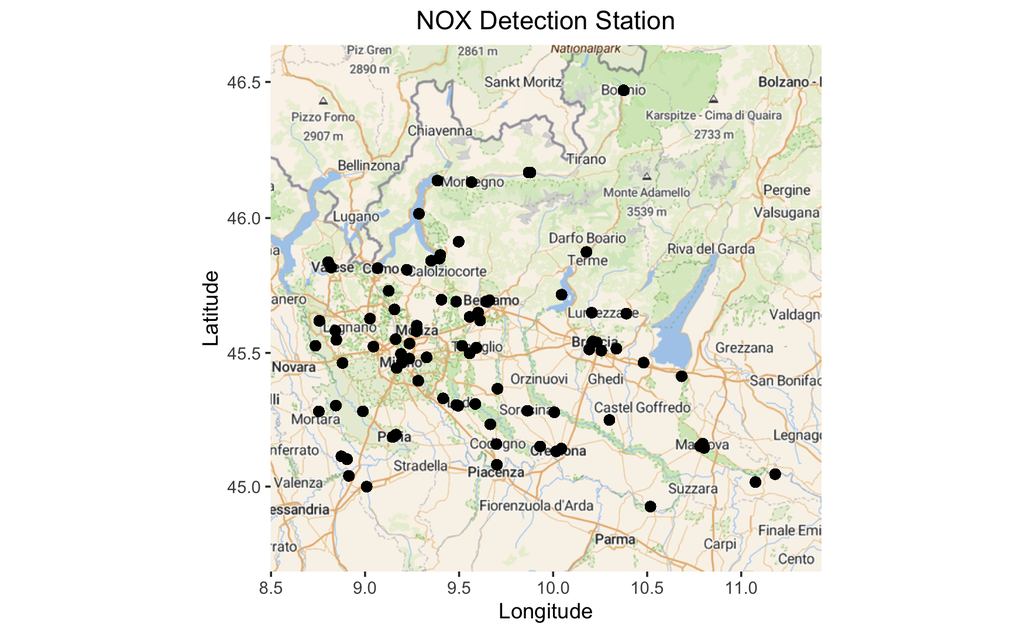

```r
NOX <- fullData [fullData$NomeTipoSensore == "Ossidi di Azoto",]

# no limit

# plot the detection station
plot <- ggmap(lombardiaMap) + geom_point(data = NOX,
                     aes(x = lng, y = lat), size = 2, alpha = 0.15) +
                     ggtitle("NOX Detection Station") +
                     labs(x = "Longitude", y = "Latitude") +
                     theme(plot.title = element_text(hjust = 0.5))
plot
```

Calcolo: - la media annua per stazione - la media annua per provincia

```r
# ANNUAL AVG BY STATION AND BY PROVINCE
# Convert 'Data' column to Date type
NOX$Data <- as.Date(NOX$Data)

# Calculate the annual average grouped by IdStazione for the year 2023
NOX_annual_avg_by_station <- NOX %>%
  filter(lubridate::year(Data) == 2023) %>%
  group_by(IdStazione) %>%
  summarise(Avg_Valore_Station = mean(Valore, na.rm = TRUE))

# Calculate the annual average grouped by Provincia
NOX_annual_avg_by_province <- NOX_annual_avg_by_station %>%
  left_join(NOX %>% select(IdStazione, Provincia) %>% distinct(), by = "IdStazione") %>%
  group_by(Provincia) %>%
  summarise(Avg_Valore_Province = mean(Avg_Valore_Station, na.rm = TRUE))

# Adding lat and lng for station
NOX_annual_avg_by_station <- merge(NOX_annual_avg_by_station, stationData[stationData$NomeTipoSensore == "Ossidi di Azoto",])

# Adding lat and lng for provinces
NOX_annual_avg_by_province <- merge(NOX_annual_avg_by_province, province, by="Provincia")
```

Plot:densità annua per stazione + densità annua per provincia

```r
color_scale <- scale_fill_gradient(low = "green", high = "red", name = "Average yearly value")

# Plot the detection station with color based on Avg_Valore_Station and add density map
plot <- ggmap(lombardiaMap) +
  stat_density_2d(data = NOX_annual_avg_by_station, aes(x = lng, y = lat, fill = Avg_Valore_Station),
                 geom = "polygon", alpha = 0.08 , binwidth=0.05) +  # Add density map
  geom_point(data = NOX_annual_avg_by_station, aes(x = lng, y = lat, fill = Avg_Valore_Station),
             size = 3, alpha = 0.8, shape = 21) +  # shape = 21 for filled circles
  color_scale +
  labs(x = "Longitude", y = "Latitude") +
  theme(plot.title = element_text(hjust = 0.5)) +
  theme(plot.title = element_text(hjust = 0.5),
        axis.text.x = element_text(size = 11),
        axis.text.y = element_text(size = 11),
        axis.title.x = element_text(size = 16),
        axis.title.y = element_text(size = 16),
        legend.position = "top")

ggsave(plot, file="annualDensityNOXStation.pdf", width = 5, height = 5)


# Assuming Avg_Valore_Station is the variable you want to use for color
color_scale <- scale_fill_gradient(low = "green", high = "red", name = "Average yearly value")

# Plot the detection station with color based on Avg_Valore_Station and add density map
plot <- ggmap(lombardiaMap) +
  stat_density_2d(data = NOX_annual_avg_by_province, aes(x = lng, y = lat, fill = Avg_Valore_Province),
                 geom = "polygon", alpha = 0.1 , binwidth=0.05) +  # Add density map
  geom_point(data = NOX_annual_avg_by_province, aes(x = lng, y = lat, fill = Avg_Valore_Province),
             size = 5, alpha = 0.8, shape = 21) +  # shape = 21 for filled circles
  color_scale +
  labs(x = "Longitude", y = "Latitude") +
  theme(plot.title = element_text(hjust = 0.5)) +
  theme(plot.title = element_text(hjust = 0.5),
        axis.text.x = element_text(size = 11),
        axis.text.y = element_text(size = 11),
        axis.title.x = element_text(size = 16),
        axis.title.y = element_text(size = 16),
        legend.position = "top")

ggsave(plot, file="annualDensityNOXZone.pdf", width = 5, height = 5)
```

+++++++++++ TEST ++++++++++++

```r
color_scale <- scale_fill_gradient(low = "green", high = "red", name = "Average yearly value")

# Plot the detection station with color based on Avg_Valore_Station and add density map
plot <- ggplot() +
  geom_sf(data = lombardia_provinces, fill = "white", color = "black") +  # White background for provinces
  stat_density_2d(data = NOX_annual_avg_by_station, aes(x = lng, y = lat, fill = Avg_Valore_Station),
                 geom = "polygon", alpha = 0.2 , bins = 25) +  # Add density map
  geom_point(data = NOX_annual_avg_by_station, aes(x = lng, y = lat, fill = Avg_Valore_Station),
             size = 3, alpha = 0.8, shape = 21) +  # shape = 21 for filled circles
  color_scale +
  labs(x = "Longitude", y = "Latitude") +
  theme(plot.title = element_text(hjust = 0.5)) +
  theme(plot.title = element_text(hjust = 0.5),
        axis.text.x = element_text(size = 11),
        axis.text.y = element_text(size = 11),
        axis.title.x = element_text(size = 16),
        axis.title.y = element_text(size = 16),
        legend.position = "top")

# Open the plot in a new window
print(plot)
```